# Rotación de cargo

Alvaro Pérez Niño

Marzo de 2024

# Problemática

En una organización, se busca comprender y prever los factores que influyen en la rotación de empleados entre distintos cargos. La empresa ha recopilado datos históricos sobre el empleo de sus trabajadores, incluyendo variables como la antigüedad en el cargo actual, el nivel de satisfacción laboral, el salario actual, edad y otros factores relevantes. La gerencia planea desarrollar un modelo de regresión logística que permita estimar la probabilidad de que un empleado cambie de cargo en el próximo período y determinar cuales factores indicen en mayor proporción a estos cambios.

Con esta información, la empresa podrá tomar medidas proactivas para retener a su talento clave, identificar áreas de mejora en la gestión de recursos humanos y fomentar un ambiente laboral más estable y tranquilo. La predicción de la probabilidad de rotación de empleados ayudará a la empresa a tomar decisiones estratégicas informadas y a mantener un equipo de trabajo comprometido y satisfecho en sus roles actuales.

## Data

```r
# Base de datos - Rotacion
library(paqueteMODELOS)
```

```r
library(dplyr)
```

```r
data("rotacion")
str(rotacion)
```

```
## tibble [1,470 × 24] (S3: tbl_df/tbl/data.frame)
##  $ Rotación                   : chr [1:1470] "Si" "No" "Si" "No" ...
##  $ Edad                       : num [1:1470] 41 49 37 33 27 32 59 30 38 36 ...
##  $ Viaje de Negocios          : chr [1:1470] "Raramente" "Frecuentemente" "Raramente" "Frecuentemente" ...
##  $ Departamento               : chr [1:1470] "Ventas" "IyD" "IyD" "IyD" ...
##  $ Distancia_Casa             : num [1:1470] 1 8 2 3 2 2 3 24 23 27 ...
##  $ Educación                  : num [1:1470] 2 1 2 4 1 2 3 1 3 3 ...
##  $ Campo_Educación            : chr [1:1470] "Ciencias" "Ciencias" "Otra" "Ciencias" ...
##  $ Satisfacción_Ambiental     : num [1:1470] 2 3 4 4 1 4 3 4 4 3 ...
##  $ Genero                     : chr [1:1470] "F" "M" "M" "F" ...
##  $ Cargo                      : chr [1:1470] "Ejecutivo_Ventas" "Investigador_Cientifico" "Tecnico_Laboratorio" "Investigador_Cientifico" ...
##  $ Satisfación_Laboral        : num [1:1470] 4 2 3 3 2 4 1 3 3 3 ...
##  $ Estado_Civil               : chr [1:1470] "Soltero" "Casado" "Soltero" "Casado" ...
##  $ Ingreso_Mensual            : num [1:1470] 5993 5130 2090 2909 3468 ...
##  $ Trabajos_Anteriores        : num [1:1470] 8 1 6 1 9 0 4 1 0 6 ...
##  $ Horas_Extra                : chr [1:1470] "Si" "No" "Si" "Si" ...
##  $ Porcentaje_aumento_salarial: num [1:1470] 11 23 15 11 12 13 20 22 21 13 ...
##  $ Rendimiento_Laboral        : num [1:1470] 3 4 3 3 3 3 4 4 4 3 ...
##  $ Años_Experiencia           : num [1:1470] 8 10 7 8 6 8 12 1 10 17 ...
##  $ Capacitaciones             : num [1:1470] 0 3 3 3 3 2 3 2 2 3 ...
##  $ Equilibrio_Trabajo_Vida    : num [1:1470] 1 3 3 3 3 2 2 3 3 2 ...
##  $ Antigüedad                 : num [1:1470] 6 10 0 8 2 7 1 1 9 7 ...
##  $ Antigüedad_Cargo           : num [1:1470] 4 7 0 7 2 7 0 0 7 7 ...
##  $ Años_ultima_promoción      : num [1:1470] 0 1 0 3 2 3 0 0 1 7 ...
##  $ Años_acargo_con_mismo_jefe : num [1:1470] 5 7 0 0 2 6 0 0 8 7 ...
```

El dataset contiene 24 atributos y 1470 observaciones. De los cuales cuenta con 8 variables categoricas, 11 variables cuantitativas y 5 variables ordinales. Adicionalmente o se presenta perdida de informacion u observaciones incompletas:

```r
grafico <-md.pattern(rotacion, rotate.names = TRUE)
```

```
##  /\     /\
## {  `---'  }
## {  O   O  }
## ==>  V <==  No need for mice. This data set is completely observed.
##  \  \|/  /
##   `-----'
```

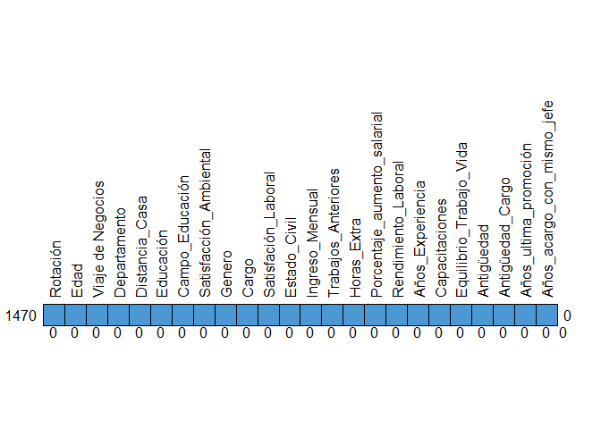

# Solución

## 1. Selección de variables

Seleccione 3 variables categóricas (distintas de rotación) y 3 variables cuantitativas, que se consideren estén relacionadas con la rotación.

### 1.1 Variables Categóricas

- **Horas extra:** `$Horas_Extra : chr [1:1470] "Si" "No" "Si" "Si" ...`

Se espera que los empleados que trabajan horas extras tengan una mayor probabilidad de rotación que las persona que no trabajan horas extras; debido a tienen menor tiempo para las actividades personales.

- **Estado_Civil:** `$Estado_Civil : chr [1:1470] "Soltero" "Casado" "Soltero" "Casado" ...`

Se espera que los empleados solteros o divorciados tengan una mayor probabilidad de rotación que los demás empleados casados debido a su estabilidad familiar y/o económica.

- **Cargo:** `$Cargo : chr [1:1470] "Ejecutivo_Ventas" "Investigador_Cientifico" "Tecnico_Laboratorio" ...`

Se espera que los empleados con cargos de tipo operativo, presenten una mayor rotacion en comparacion a los cargos directivos por su naturaleza.

### 1.2 Variables Cuantitativas

- **Edad:** `$Edad : num [1:1470] 41 49 37 33 27 32 59 30 38 36 ...`

Se espera que las personas jovenes presenten una mayor rotación en comparación de las personas mas adultas

- **Años experiencia:** `$Años_Experiencia : num [1:1470] 8 10 7 8 6 8 12 1 10 17 ...`

se espera que las personas con menos años de experiencia presenten una mayor rotación en comparación con las personas con mas años de experiencia.

- **Distancia Trabajo - Casa:** `$Distancia_Casa : num [1:1470] 1 8 2 3 2 2 3 24 23 27 ...`

Se espera que las personas que viven a una mayor distancia del lugar trabajo roten en una mayor frecuencia en comparación con las personas que viven mas cerca al lugar de trabajo.

## 2. Análisis univariado

Realiza un análisis univariado (caracterización) de la información contenida en la base de datos *rotacion*.

### 2.1 Variables Categóricas

```r
Horas_Extra <- prop.table(table(rotacion$Horas_Extra)) * 100
print(Horas_Extra)
```

```
##
##       No       Si
## 71.70068 28.29932
```

```r
Estado_Civil <- prop.table(table(rotacion$Estado_Civil)) * 100
print(Estado_Civil)
```

```
##
##     Casado Divorciado    Soltero
##   45.78231   22.24490   31.97279
```

```r
Cargo <- prop.table(table(rotacion$Cargo)) * 100
print(Cargo)
```

```
##
##  Director_Investigación    Director_Manofactura        Ejecutivo_Ventas
##                5.442177                9.863946               22.176871
##                 Gerente Investigador_Cientifico        Recursos_Humanos
##                6.938776               19.863946                3.537415
##     Representante_Salud    Representante_Ventas     Tecnico_Laboratorio
##                8.911565                5.646259               17.619048
```

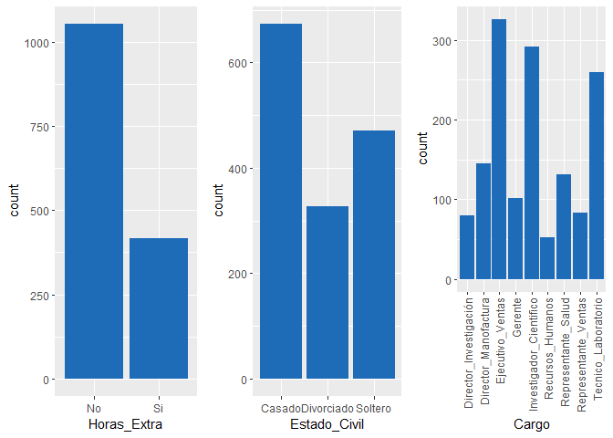

```r
g1 = ggplot(rotacion, aes(x = Horas_Extra)) + geom_bar(fill="#1E6BB8") + theme_gray()
g2 = ggplot(rotacion, aes(x = Estado_Civil)) + geom_bar(fill="#1E6BB8") + theme_gray()
g3 = ggplot(rotacion, aes(x = Cargo)) + geom_bar(fill="#1E6BB8") + theme_gray() +
  theme(axis.text.x = element_text(angle = 90, vjust = 0.5, hjust=1))
ggarrange(g1, g2, g3, ncol = 3, nrow = 1)
```

### 2.2 Variables Cuantitativas

```r
variables_cuan_resumir <- c("Edad", "Años_Experiencia", "Distancia_Casa")
summary(rotacion[variables_cuan_resumir])
```

```
##       Edad       Años_Experiencia Distancia_Casa
##  Min.   :18.00   Min.   : 0.00    Min.   : 1.000
##  1st Qu.:30.00   1st Qu.: 6.00    1st Qu.: 2.000
##  Median :36.00   Median :10.00    Median : 7.000
##  Mean   :36.92   Mean   :11.28    Mean   : 9.193
##  3rd Qu.:43.00   3rd Qu.:15.00    3rd Qu.:14.000
##  Max.   :60.00   Max.   :40.00    Max.   :29.000
```

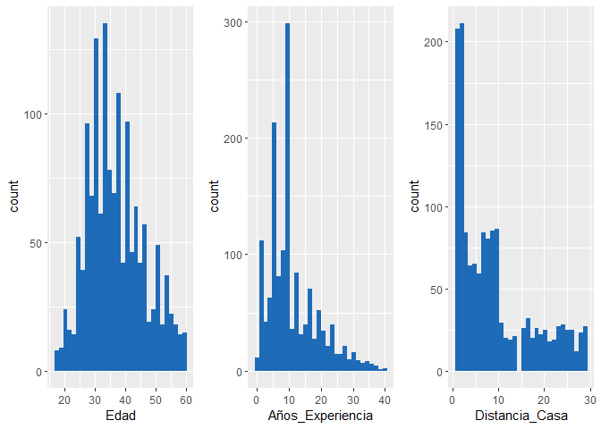

```r
g4 = ggplot(rotacion, aes(x = Edad)) + geom_histogram(fill="#1E6BB8") + theme_gray()
g5 = ggplot(rotacion, aes(x = Años_Experiencia)) + geom_histogram(fill="#1E6BB8") + theme_gray()
g6 = ggplot(rotacion, aes(x = Distancia_Casa)) + geom_histogram(fill="#1E6BB8") + theme_gray()
ggarrange(g4, g5, g6, ncol = 3, nrow = 1)
```

## 3. Análisis bivariado

Realiza un análisis de bivariado en donde la variable respuesta sea rotacion codificada de la siguiente manera `(y=1 es si rotación, y=0 es no rotación)`. Con base en estos resultados identifique cuales son las variables determinantes de la rotación e interpretar el signo del coeficiente estimado. Compare estos resultados con la hipotesis planteada en el punto 2.

### 3.1 Variables Categóricas

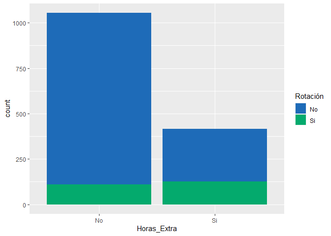

```r
colores_rotacion <- c("#1E6BB8", "#04AA6D")
ggplot(rotacion, aes(x = Horas_Extra, fill = Rotación)) + geom_bar() +
  scale_fill_manual(values = colores_rotacion)
```

```r
chisq.test(table(rotacion$Horas_Extra, rotacion$Rotación))
```

```
##
##  Pearson's Chi-squared test with Yates' continuity correction
##
## data:  table(rotacion$Horas_Extra, rotacion$Rotación)
## X-squared = 87.564, df = 1, p-value < 2.2e-16
```

**Análisis:** Se rechaza hipotesis nula y se acepta hipotesis alterna, donde se evidencia que las Horas_Extra influye en la rotación del personal.

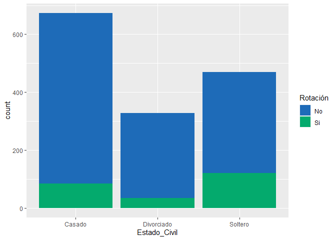

```r
ggplot(rotacion, aes(x = Estado_Civil, fill = Rotación)) + geom_bar() +
  scale_fill_manual(values = colores_rotacion)
```

```r
chisq.test(table(rotacion$Estado_Civil, rotacion$Rotación))
```

```
##
##  Pearson's Chi-squared test
##
## data:  table(rotacion$Estado_Civil, rotacion$Rotación)
## X-squared = 46.164, df = 2, p-value = 9.456e-11
```

**Análisis:** Se rechaza hipotesis nula y se acepta hipotesis alterna, donde se evidencia que el Estado_Civil influye en la rotación del personal.

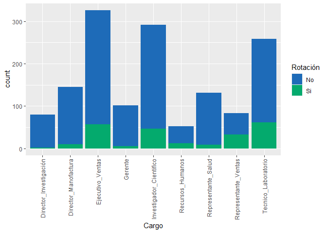

```r
ggplot(rotacion, aes(x = Cargo, fill = Rotación)) + geom_bar() +
  scale_fill_manual(values = colores_rotacion) +
  theme(axis.text.x = element_text(angle = 90, vjust = 0.5, hjust=1))
```

```r
chisq.test(table(rotacion$Cargo, rotacion$Rotación))
```

```
##
##  Pearson's Chi-squared test
##
## data:  table(rotacion$Cargo, rotacion$Rotación)
## X-squared = 86.19, df = 8, p-value = 2.752e-15
```

**Análisis:** Se rechaza hipotesis nula y se acepta hipotesis alterna, donde se evidencia que el Cargo influye en la rotación del personal.

### 3.2 Variables Cuantitativas

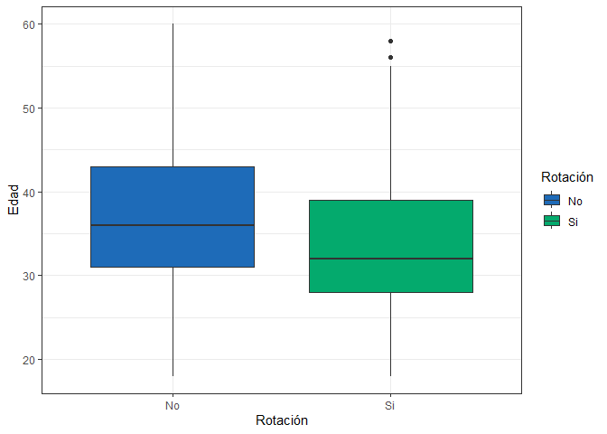

```r
ggplot(rotacion,aes(x=Rotación,y=Edad,fill=Rotación)) + geom_boxplot()+theme_bw() +
  scale_fill_manual(values = colores_rotacion)
```

```r
t.test(rotacion$Edad ~ rotacion$Rotación)
```

```
##
##  Welch Two Sample t-test
##
## data:  rotacion$Edad by rotacion$Rotación
## t = 5.8291, df = 316.94, p-value = 1.371e-08
## alternative hypothesis: true difference in means between group No and group Si is not equal to 0
## 95 percent confidence interval:
##  2.619728 5.289170
## sample estimates:
## mean in group No mean in group Si
##         37.56204         33.60759
```

**Análisis:** Se rechaza hipotesis nula y se acepta hipotesis alterna, donde se evidencia que la Edad influye en la rotación del personal.

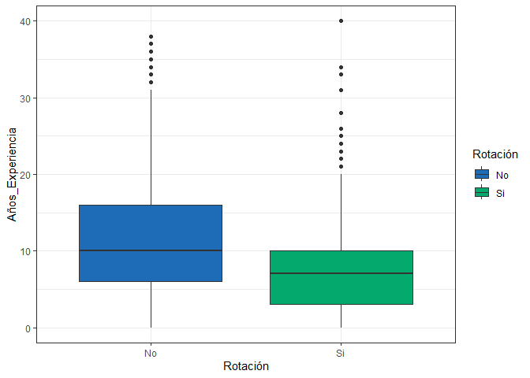

```r
ggplot(rotacion,aes(x=Rotación,y=Años_Experiencia,fill=Rotación)) + geom_boxplot()+theme_bw() +
  scale_fill_manual(values = colores_rotacion)
```

```r
t.test(rotacion$Años_Experiencia ~ rotacion$Rotación)
```

```
##
##  Welch Two Sample t-test
##
## data:  rotacion$Años_Experiencia by rotacion$Rotación
## t = 7.0192, df = 350.88, p-value = 1.16e-11
## alternative hypothesis: true difference in means between group No and group Si is not equal to 0
## 95 percent confidence interval:
##  2.604401 4.632019
## sample estimates:
## mean in group No mean in group Si
##        11.862936         8.244726
```

**Análisis:** Se rechaza hipotesis nula y se acepta hipotesis alterna, donde se evidencia que los Años de Experiencia influye en la rotación del personal.

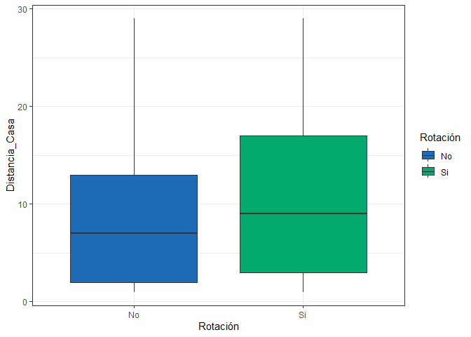

```r
ggplot(rotacion,aes(x=Rotación,y=Distancia_Casa,fill=Rotación)) + geom_boxplot()+theme_bw() +
  scale_fill_manual(values = colores_rotacion)
```

```r
t.test(rotacion$Distancia_Casa ~ rotacion$Rotación)
```

```
##
##  Welch Two Sample t-test
##
## data:  rotacion$Distancia_Casa by rotacion$Rotación
## t = -2.8882, df = 322.72, p-value = 0.004137
## alternative hypothesis: true difference in means between group No and group Si is not equal to 0
## 95 percent confidence interval:
##  -2.8870025 -0.5475146
## sample estimates:
## mean in group No mean in group Si
##         8.915653        10.632911
```

**Análisis:** Se rechaza hipotesis nula y se acepta hipotesis alterna, donde se evidencia que la Distancia del trabajo - casa influye en la rotación del personal.

## 4. Estimación del modelo

Realiza la estimación de un modelo de regresión logístico en el cual la variable respuesta es rotacion `(y=1 es si rotación, y=0 es no rotación)` y las covariables las 6 seleccionadas en el punto 1. Interprete los coeficientes del modelo y la significancia de los parámetros.

```r
rotacion$Rotacion_nume <- ifelse(rotacion$Rotación == "Si", 1, 0)
modelo <- glm(Rotacion_nume ~ Horas_Extra + Estado_Civil + Cargo + Edad +
                Años_Experiencia + Distancia_Casa, data = rotacion, family = "binomial")

summary(modelo)
```

```
##
## Call:
## glm(formula = Rotacion_nume ~ Horas_Extra + Estado_Civil + Cargo +
##     Edad + Años_Experiencia + Distancia_Casa, family = "binomial",
##     data = rotacion)
##
## Coefficients:
##                               Estimate Std. Error z value Pr(>|z|)
## (Intercept)                  -3.538489   0.854901  -4.139 3.49e-05 ***
## Horas_ExtraSi                 1.575371   0.163008   9.664  < 2e-16 ***
## Estado_CivilDivorciado       -0.280976   0.232477  -1.209 0.226809
## Estado_CivilSoltero           0.882699   0.174045   5.072 3.94e-07 ***
## CargoDirector_Manofactura     0.714976   0.808707   0.884 0.376644
## CargoEjecutivo_Ventas         1.722107   0.756258   2.277 0.022778 *
## CargoGerente                  0.807995   0.866447   0.933 0.351059
## CargoInvestigador_Cientifico  1.373494   0.770301   1.783 0.074576 .
## CargoRecursos_Humanos         2.331151   0.828158   2.815 0.004880 **
## CargoRepresentante_Salud      0.777679   0.815446   0.954 0.340243
## CargoRepresentante_Ventas     2.690182   0.801976   3.354 0.000795 ***
## CargoTecnico_Laboratorio      2.146032   0.766834   2.799 0.005133 **
## Edad                         -0.020388   0.011787  -1.730 0.083677 .
## Años_Experiencia             -0.021538   0.018274  -1.179 0.238562
## Distancia_Casa                0.032251   0.009443   3.415 0.000637 ***
## ---
## Signif. codes:  0 '***' 0.001 '**' 0.01 '*' 0.05 '.' 0.1 ' ' 1
##
## (Dispersion parameter for binomial family taken to be 1)
##
##     Null deviance: 1298.6  on 1469  degrees of freedom
## Residual deviance: 1059.0  on 1455  degrees of freedom
## AIC: 1089
##
## Number of Fisher Scoring iterations: 6
```

```r
exp(modelo$coefficients)
```

```
##                  (Intercept)                Horas_ExtraSi
##                   0.02905721                   4.83253651
##       Estado_CivilDivorciado          Estado_CivilSoltero
##                   0.75504645                   2.41741597
##    CargoDirector_Manofactura        CargoEjecutivo_Ventas
##                   2.04413664                   5.59630560
##                 CargoGerente CargoInvestigador_Cientifico
##                   2.24340458                   3.94912380
##        CargoRecursos_Humanos     CargoRepresentante_Salud
##                  10.28978196                   2.17641437
##    CargoRepresentante_Ventas     CargoTecnico_Laboratorio
##                  14.73435265                   8.55085814
##                         Edad             Años_Experiencia
##                   0.97981799                   0.97869232
##               Distancia_Casa
##                   1.03277707
```

**Análisis:**

## 5. Evaluación

Evaluar el poder predictivo del modelo con base en la curva ROC y el AUC.

```r
prob_pred <- predict(modelo, type = "response")
roc_obj <- roc(rotacion$Rotacion_nume, prob_pred)
```

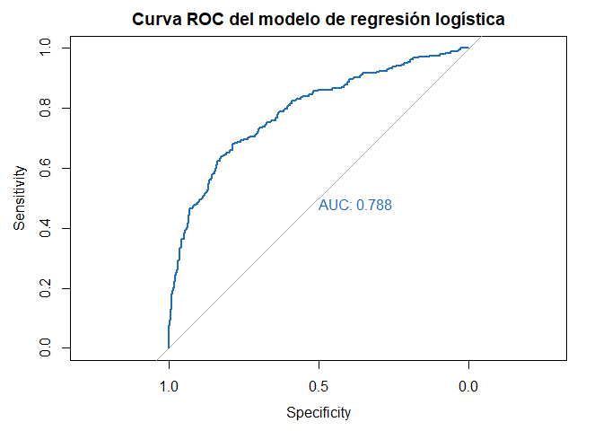

```r
auc <- auc(roc_obj)

plot(roc_obj, main = "Curva ROC del modelo de regresión logística",
     col = "#1E6BB8", lwd = 2, print.auc = TRUE)
```

**Análisis:** En este caso, un AUC de 0.788 sugiere que el modelo tiene una capacidad aceptable para predecir la rotación de los empleados en función de las variables predictoras incluidas en el modelo de regresión logística.

## 6. Predicciones

Realiza una predicción la probabilidad de que un individuo (hipotético) rote y defina un corte para decidir si se debe intervenir a este empleado o no (posible estrategia para motivar al empleado).

```r
nuevo_empleado <- data.frame(Horas_Extra = "Si",
                               Estado_Civil = "Soltero",
                               Cargo = "Ejecutivo_Ventas",
                               Edad = 35,
                               Años_Experiencia = 4,
                               Distancia_Casa = 15)

prob_pred_nuevo <- predict(modelo, newdata = nuevo_empleado, type = "response")

umbral <- 0.5

if (prob_pred_nuevo > umbral) {
  mensaje <- "Existe probabilidad de rotación. Se recomienda intervenir con
  el empleado para motivarlo."
} else {
  mensaje <- "No Existe la probabilidad de rotación. No es necesario intervenir con
  el empleado en este momento."
}

cat(mensaje, prob_pred_nuevo)
```

```
## Existe probabilidad de rotación. Se recomienda intervenir con
##   el empleado para motivarlo. 0.5807155
```

## 7. Conclusiones

En las conclusiones adicione una discución sobre cuál sería la estrategia para disminuir la rotación en la empresa (con base en las variables que resultaron significativas en el punto 3).

## 8. Anexos

Código fuente –> [Clic Aquí](https://raw.githubusercontent.com/aperezn298/METDAct03/main/Actividad03.Rmd)

## 9. Autor

*Alvaro Perez Niño – Estudiante*

Maestría en Ciencia de Datos

Universidad Javeriana - Cali

**Código:** 8986470

**Email:** aperezn892@javerianacali.edu.co